# Regra e taylor

Rodrigo Ferreira Costa Pinto

2024-03-05

## Introducao

Knight (2006) fez uma distinção entre risco e incerteza. O risco é algo que pode ser calculado porque se baseia na probabilidade conhecida de um evento acontecer, permitindo que os produtores o considerem ao calcular a melhor forma de maximizar seus lucros. A incerteza é o desconhecimento do que vai acontecer no futuro (Knight, 2006).

Nos modelos tradicionais, diante dessa imprevisibilidade, criam-se naturalmente certos cenários mais conservadores na economia (Bernanke, 1983), impactando negativamente os investimentos, pois nesse clima de incerteza os consumidores optam por postergar suas decisões até que se possa mensurar mais precisamente o resultado das suas escolhas.

A incerteza na economia vai ser medida pelo índice de incerteza econômico-política (EPU) desenvolvido por **Baker, Davis e Bloom** (2016). Esse índice conta quantas vezes palavras relacionadas à incerteza econômica ou política aparecem em jornais populares. A ideia principal por trás desse índice é que os agentes econômicos usam as notícias desses jornais para ter uma noção de quão incerta está a economia.  
O sentimento está intimamente ligado à escolha das palavras usadas na escrita. Ao selecionar um conjunto específico de palavras para análise, é possível determinar o tom do texto. A tonalidade resultante, combinada com o peso atribuído a cada palavra, permite obter um parâmetro que expressa o sentimento desejado.

Fazendo uma análise do sentimento das atas do Comitê de Política Monetária (COPOM), é possível captar as nuances do discurso dos membros do comitê em relação às perspectivas econômicas, às incertezas políticas e aos possíveis impactos nas decisões de política monetária. Através dessa análise textual, é viável identificar os momentos de maior cautela ou otimismo por parte dos dirigentes, assim como compreender como as informações econômicas e políticas influenciam suas percepções e abordagens. Essa investigação contribui para uma compreensão mais aprofundada dos fatores que moldam as decisões do COPOM e sua orientação em relação à política monetária.

## Objetivo

O objetivo é averiguar o efeito do principal veículo de comunicação do Banco Central do Brasil, as atas das reuniões do Comitê de Política Monetária (COPOM), sobre o mercado de juros futuros no período de 2003 a 2023.

## Metodologia

Os dados usados nesse trabalho foram coletados no site do BCB timed series e foram transformado em log usando logaritmo natural.

### Deflacionar

A serie foi deflacionada usando essa formula:

\[ S_{\text{deflacionada}} = \frac{S_{\text{nominal}}}{\text{Índice de Deflator}} \]

Onde:

- - \( S_{\text{deflacionada}} \) é a série deflacionada (ajustada para remover o efeito da inflação).
- - \( S_{\text{nominal}} \) é a série nominal (sem ajuste para inflação).
- - \( \text{Índice de Deflator} \) é o índice que representa a variação dos preços ao longo do tempo.

### Hiato

Para calcular o hiato foi usado o Hodrick-Prescottn hp filter  
\[ \text{Minimizar } \sum_{t=1}^{T} \left[ (y_t - \bar{y}_t)^2 + \lambda(\Delta^2 y_t)^2 \right] \]

Onde:

- - \( y_t \) é o valor observado da série temporal no tempo \( t \).
- - \( \bar{y}_t \) é a tendência de longo prazo (componente de tendência) no tempo \( t \).
- - \( \Delta^2 y_t \) é a variação quadrática da série temporal no tempo \( t \).
- - \( \lambda \) é o parâmetro de suavização, que controla o grau de suavização do componente cíclico em relação ao componente de tendência. Quanto maior o valor de \( \lambda \), mais suavizado será o componente cíclico.

  O objetivo do filtro HP é encontrar a tendência de longo prazo (\( \bar{y}_t \)) que minimize a soma ponderada dos desvios quadráticos entre os valores observados da série temporal e a tendência, juntamente com a variação quadrática da série temporal. Isso ajuda a separar o componente cíclico (variações de curto prazo) do componente de tendência (variação de longo prazo) da série temporal.

### Testes

#### Heterocedasticidade

Heterocedasticidade refere-se à situação em que a variância dos erros de um modelo estatístico não é constante ao longo do tempo ou em diferentes níveis das variáveis independentes.

- Goldfeld-Quandt.
- Breusch-Pagan.
- O teste de White

#### Autocorrelação

Autocorrelação é quando existe uma relacao entre os erros em uma observacao e os erros em observacoes anteriores.

- Durbin-Watson
- Teste ARCH
- Box-Pierce

#### Multicolinearidade

multicolinearidade existe quando duas ou mais variaveis independentes sao altamente correlacionadas, tornando dificil isolar seus efeitos individuais na variavel dependente

- BOX

#### **WEB SCRAPING E PRÉ-PROCESSAMENTO**

A coleta de dados textuais para análise de sentimento é um passo fundamental no processo de pesquisa. Para isso, foi empregada a técnica de Web Scraping, que consiste na extração automatizada de informações de páginas da web para análise posterior.No contexto desta pesquisa, o Web Scraping foi utilizado para coletar das atas do copom , que são disponibilizadas pelo Banco Central do Brasil em seu site.Essa técnica permitiu a obtenção das informações necessárias para análise de sentimento nas atas do COPOM, que são importantes documentos que registram as discussões e decisões relacionadas à política monetária no Brasil.

#### **TOKENIZAÇÃO**

Após a coleta dos textos é feito o processamento dele para ser feito sua análise, Primeiro se faz a tokenização do texto é o processo de dividir o texto em unidades individuais de palavras.

Então é feito técnicas para facilitar a análise primeiro removendo stop words usando a biblioteca do NTK, posteriormente é feito o stemming para reduzir as palavras às suas formas básicas, removendo sufixos e prefixos. O objetivo é agrupar palavras relacionadas sob sua forma raiz, o que pode ajudar a melhorar a precisão e eficiência de análises.

#### **DICIONÁRIO DE SENTIMENTO**

Em seguida a ter os dados processados é necessário se ter um dicionário de sentimento, estes dicionários classificam um grande conjunto de palavras comumente usadas em documentos em categorias como “positiva”, “negativa”, etc. o dicionário usado para esse trabalho vai ser Loughran e Mcdonald (2011) (L&M) o qual foi criado especificamente para o ambiente econômico-financeiro. Então é comparado os tokens das palavras com o dicionário para ter o sentimento de cada palavra.

#### **Criacao da pontuacao do sentimento**

O dicionário Loughran-McDonald classifica as palavras em seis categorias de sentimento importantes em contextos financeiros:

1. **Negative**: Palavras que denotam uma conotação negativa ou pessimista.
2. **Positive**: Palavras que denotam uma conotação positiva ou otimista.
3. **Litigious**: Palavras relacionadas a litígios, disputas legais ou atividades judiciais.
4. **Uncertainty**: Palavras que indicam incerteza, dúvida ou falta de clareza.
5. **Constraining**: Palavras que denotam restrição, limitação ou impedimento.
6. **Superfluous**: Palavras que são consideradas desnecessárias, excessivas ou redundantes.

   Para pontuar cada sentimento foi usado essa metrica

   ```
   sentiment == "negative" ~ -1,
   sentiment == "positive" ~ 1.5,
   sentiment == "uncertainty" ~ -0.8,
   sentiment == "constraining" ~ -0.5,
   ```

   Entao foi obtido um numero que é a pontuacao d sentimento.

## Estimacao dos modelos

### Modelo entre 2003 e 2023

```r
summary(`modelo_2003-02-01_até_2023-12-01`)
```

```
##
## Time series regression with "numeric" data:
## Start = 1, End = 249
##
## Call:
## dynlm(formula = formula, data = dados_filtrados)
##
## Residuals:
##       Min        1Q    Median        3Q       Max
## -0.102036 -0.008415  0.000514  0.008347  0.160756
##
## Coefficients:
##                                      Estimate Std. Error t value Pr(>|t|)
## (Intercept)                         1.273e-03  2.850e-03   0.446  0.65567
## desvio                             -4.900e-03  2.907e-03  -1.686  0.09310 .
## hiato                               2.178e-03  3.061e-03   0.712  0.47743
## lag(selic, 1)                       6.733e-01  6.287e-02  10.709  < 2e-16 ***
## lag(selic, 2)                       1.874e-01  6.279e-02   2.985  0.00312 **
## lag(pontuacao_total_sentimento, 1)  1.418e-05  1.634e-05   0.868  0.38642
## ---
## Signif. codes:  0 '***' 0.001 '**' 0.01 '*' 0.05 '.' 0.1 ' ' 1
##
## Residual standard error: 0.02743 on 243 degrees of freedom
##   (2 observations deleted due to missingness)
## Multiple R-squared:  0.7106, Adjusted R-squared:  0.7046
## F-statistic: 119.3 on 5 and 243 DF,  p-value: < 2.2e-16
```

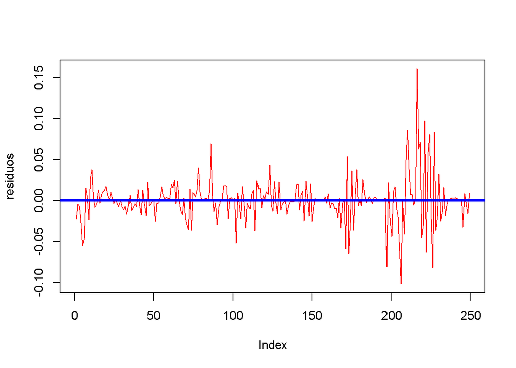

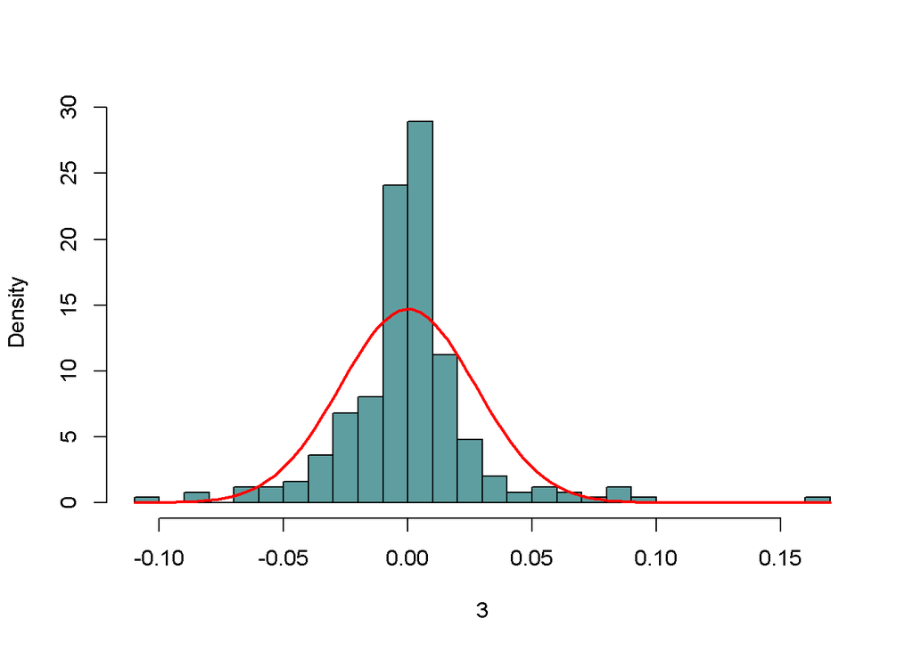

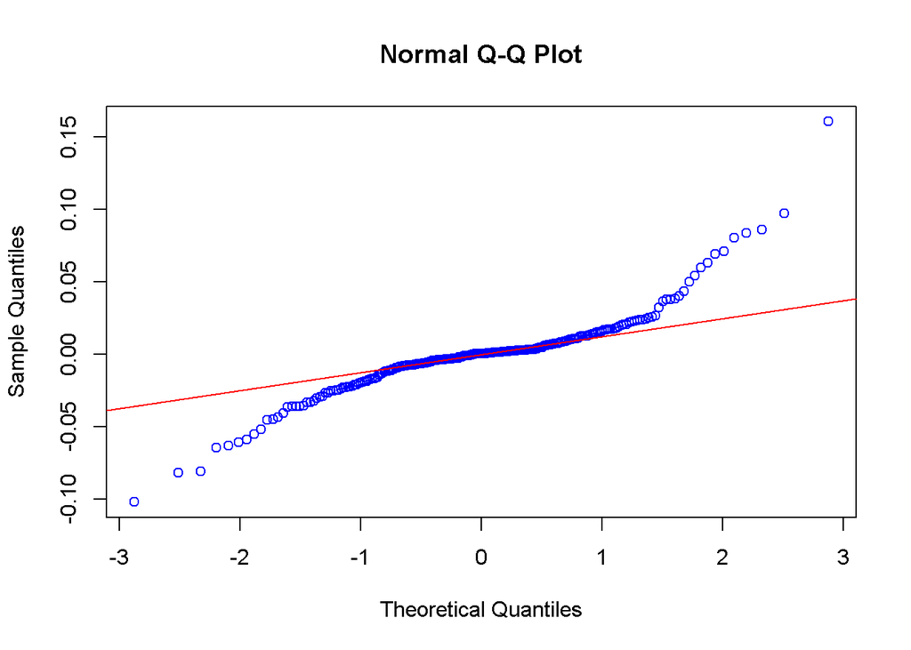

[output not shown]

[output cut: 163 more lines]

```
## $Box.test
##
##  Box-Pierce test
##
## data:  residuos
## X-squared = 47.159, df = 12, p-value = 4.376e-06
##
##
## $adf
##
##  Augmented Dickey-Fuller Test
##
## data:  residuos
## Dickey-Fuller = -4.3968, Lag order = 6, p-value = 0.01
## alternative hypothesis: stationary
```

```r
analisar_modelo(`modelo_2003-02-01_até_2023-12-01`)
```

### Modelo entre 2003 e 2010

```r
summary(`modelo_2003-02-01_até_2010-12-01`)
```

```
##
## Time series regression with "numeric" data:
## Start = 1, End = 93
##
## Call:
## dynlm(formula = formula, data = dados_filtrados)
##
## Residuals:
##       Min        1Q    Median        3Q       Max
## -0.049991 -0.007683  0.000751  0.008383  0.067543
##
## Coefficients:
##                                      Estimate Std. Error t value Pr(>|t|)
## (Intercept)                        -7.001e-04  3.708e-03  -0.189    0.851
## desvio                             -5.346e-03  6.080e-03  -0.879    0.382
## hiato                               3.391e-03  1.374e-02   0.247    0.806
## lag(selic, 1)                       9.173e-01  1.083e-01   8.474 5.36e-13 ***
## lag(selic, 2)                      -9.030e-02  1.069e-01  -0.845    0.400
## lag(pontuacao_total_sentimento, 1)  7.423e-06  1.759e-05   0.422    0.674
## ---
## Signif. codes:  0 '***' 0.001 '**' 0.01 '*' 0.05 '.' 0.1 ' ' 1
##
## Residual standard error: 0.01743 on 87 degrees of freedom
##   (2 observations deleted due to missingness)
## Multiple R-squared:  0.7216, Adjusted R-squared:  0.7056
## F-statistic:  45.1 on 5 and 87 DF,  p-value: < 2.2e-16
```

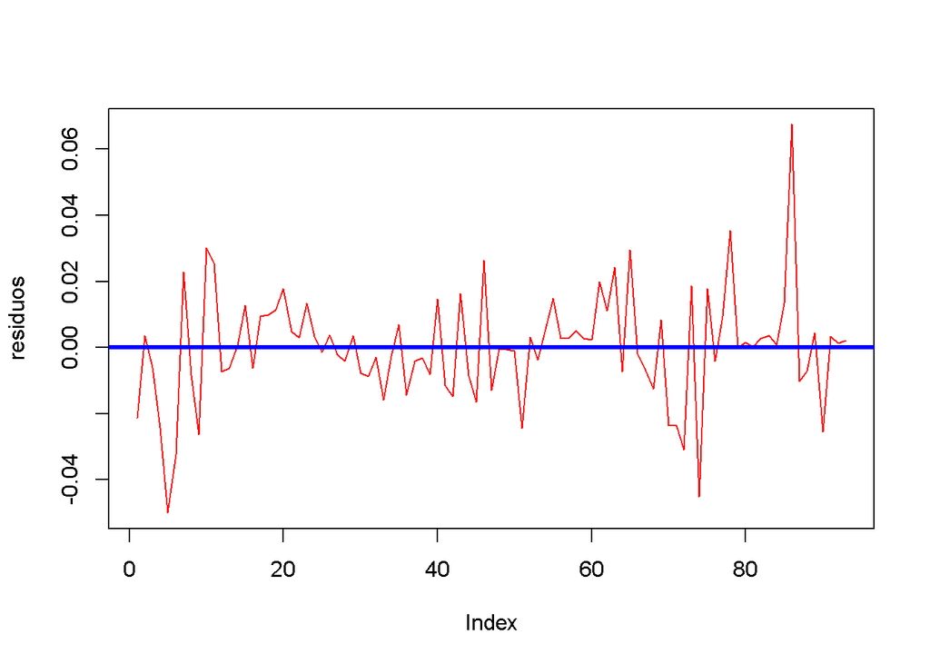

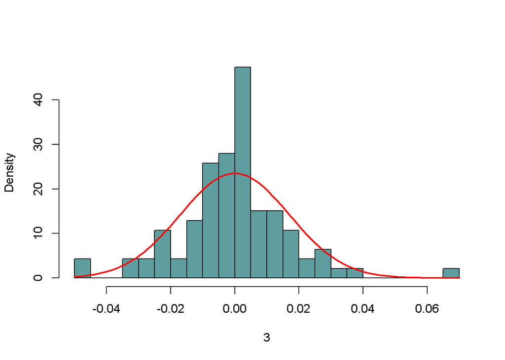

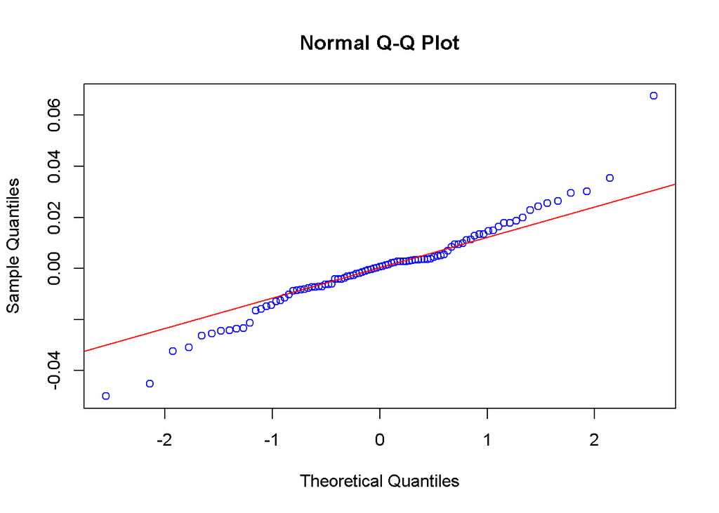

[output not shown]

[output cut: 101 more lines]

```
## $Box.test
##
##  Box-Pierce test
##
## data:  residuos
## X-squared = 12.559, df = 12, p-value = 0.4019
##
##
## $adf
##
##  Augmented Dickey-Fuller Test
##
## data:  residuos
## Dickey-Fuller = -4.3014, Lag order = 4, p-value = 0.01
## alternative hypothesis: stationary
```

```r
analisar_modelo(`modelo_2003-02-01_até_2010-12-01`)
```

### Modelo entre 2011 e 2016

```r
summary(`modelo_2011-01-01_até_2016-05-01`)
```

```
##
## Time series regression with "numeric" data:
## Start = 1, End = 63
##
## Call:
## dynlm(formula = formula, data = dados_filtrados)
##
## Residuals:
##       Min        1Q    Median        3Q       Max
## -0.038699 -0.008519 -0.000013  0.009290  0.043797
##
## Coefficients:
##                                     Estimate Std. Error t value Pr(>|t|)
## (Intercept)                        4.674e-03  2.612e-03   1.790  0.07883 .
## desvio                             5.513e-03  9.547e-03   0.577  0.56592
## hiato                              3.347e-04  7.021e-03   0.048  0.96214
## lag(selic, 1)                      4.081e-01  1.286e-01   3.174  0.00242 **
## lag(selic, 2)                      2.712e-01  1.177e-01   2.305  0.02482 *
## lag(pontuacao_total_sentimento, 1) 8.321e-05  2.905e-05   2.864  0.00585 **
## ---
## Signif. codes:  0 '***' 0.001 '**' 0.01 '*' 0.05 '.' 0.1 ' ' 1
##
## Residual standard error: 0.01577 on 57 degrees of freedom
##   (2 observations deleted due to missingness)
## Multiple R-squared:  0.714,  Adjusted R-squared:  0.6889
## F-statistic: 28.46 on 5 and 57 DF,  p-value: 2.404e-14
```

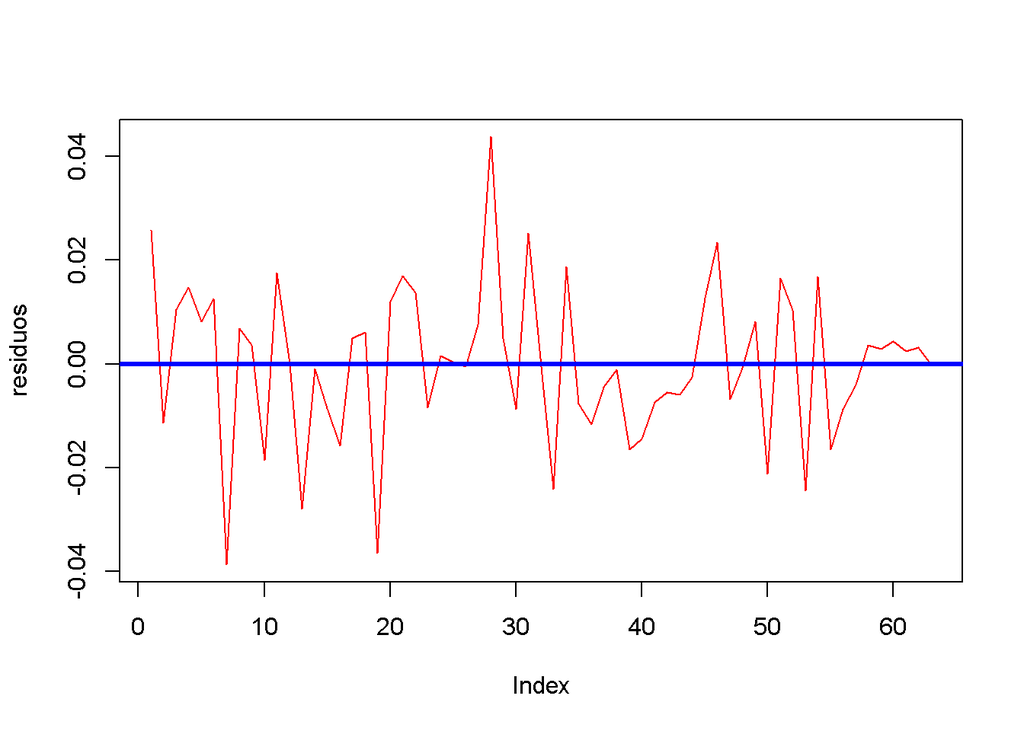

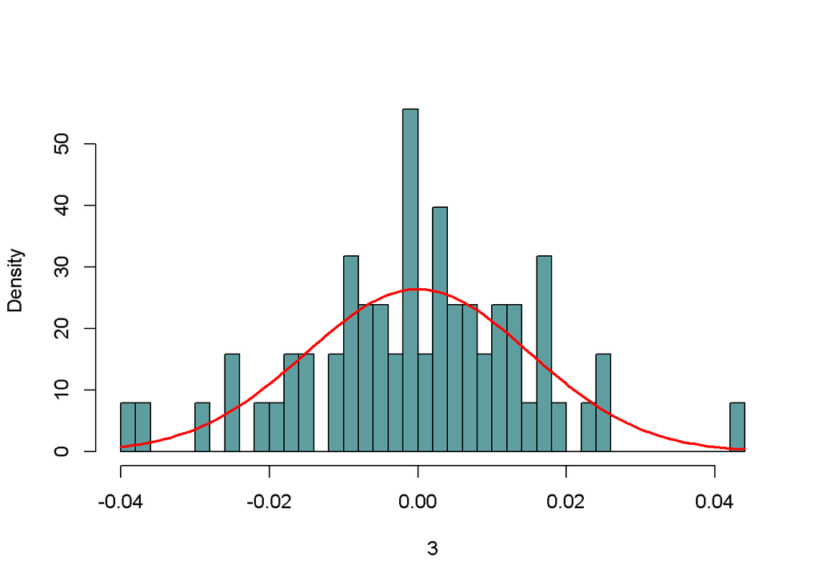

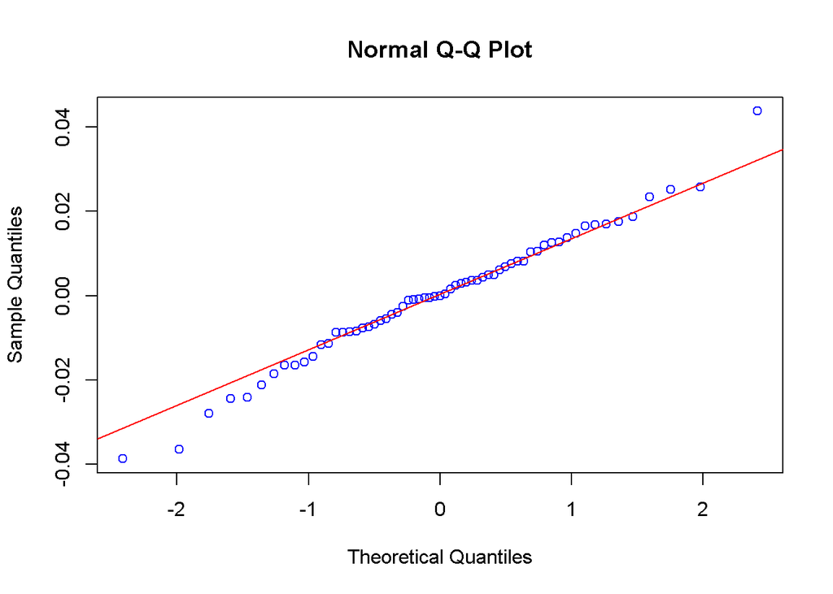

[output not shown]

[output cut: 82 more lines]

```
## $Box.test
##
##  Box-Pierce test
##
## data:  residuos
## X-squared = 19.442, df = 12, p-value = 0.07841
##
##
## $adf
##
##  Augmented Dickey-Fuller Test
##
## data:  residuos
## Dickey-Fuller = -3.5381, Lag order = 3, p-value = 0.04576
## alternative hypothesis: stationary
```

```r
analisar_modelo(`modelo_2011-01-01_até_2016-05-01`)
```

### Modelo entre 2016 e 2018

```r
summary(`modelo_2016-05-01_até_2018-12-01`)
```

```
##
## Time series regression with "numeric" data:
## Start = 1, End = 30
##
## Call:
## dynlm(formula = formula, data = dados_filtrados)
##
## Residuals:
##       Min        1Q    Median        3Q       Max
## -0.054735 -0.007222  0.001308  0.010685  0.040471
##
## Coefficients:
##                                      Estimate Std. Error t value Pr(>|t|)
## (Intercept)                        -2.144e-02  1.311e-02  -1.635   0.1150
## desvio                             -3.155e-03  1.018e-02  -0.310   0.7593
## hiato                              -1.477e-03  3.405e-03  -0.434   0.6683
## lag(selic, 1)                       2.211e-01  1.855e-01   1.192   0.2449
## lag(selic, 2)                       4.794e-01  1.796e-01   2.669   0.0134 *
## lag(pontuacao_total_sentimento, 1) -1.014e-04  7.782e-05  -1.303   0.2051
## ---
## Signif. codes:  0 '***' 0.001 '**' 0.01 '*' 0.05 '.' 0.1 ' ' 1
##
## Residual standard error: 0.02368 on 24 degrees of freedom
##   (2 observations deleted due to missingness)
## Multiple R-squared:  0.4977, Adjusted R-squared:  0.393
## F-statistic: 4.756 on 5 and 24 DF,  p-value: 0.003683
```

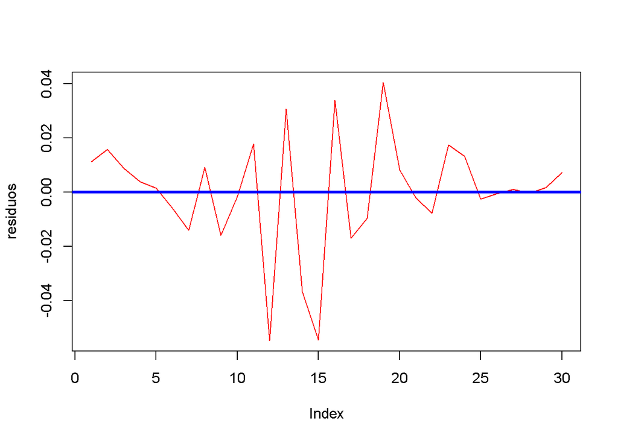

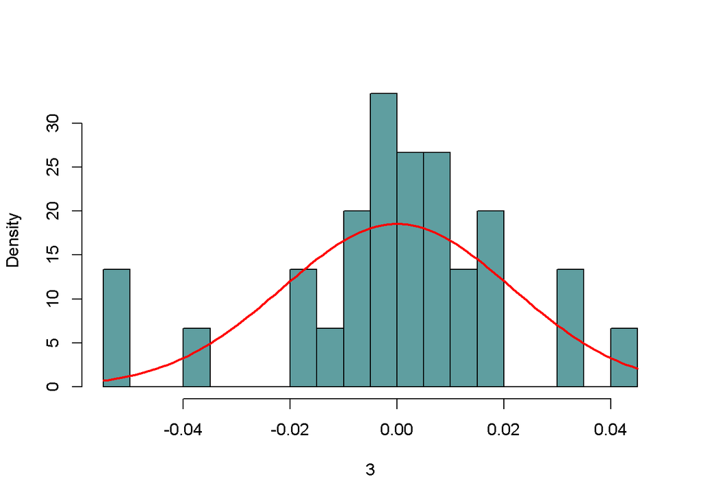

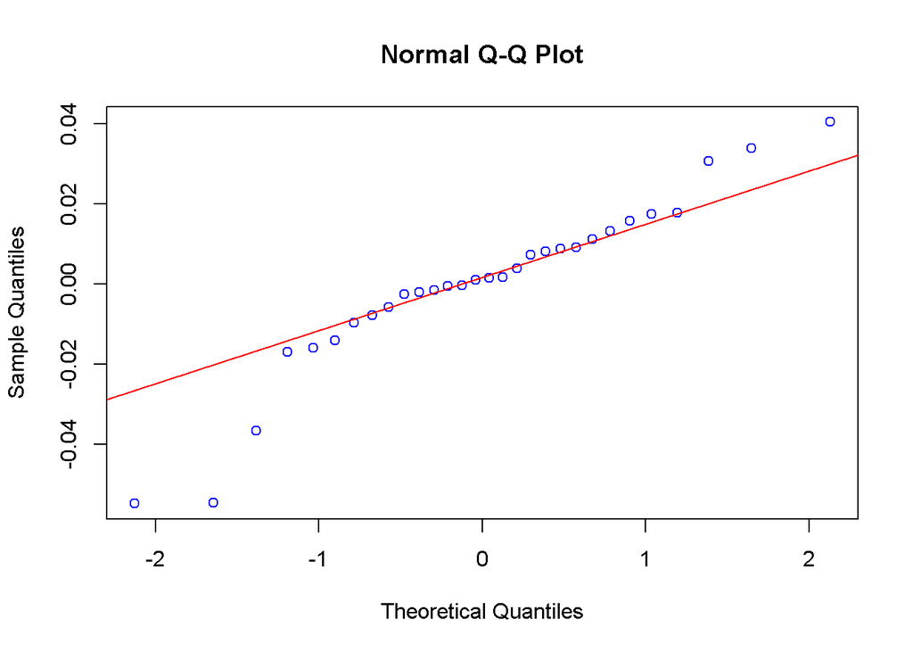

[output not shown]

[output cut: 68 more lines]

```
## $Box.test
##
##  Box-Pierce test
##
## data:  residuos
## X-squared = 17.132, df = 12, p-value = 0.1447
##
##
## $adf
##
##  Augmented Dickey-Fuller Test
##
## data:  residuos
## Dickey-Fuller = -2.4908, Lag order = 3, p-value = 0.3842
## alternative hypothesis: stationary
```

```r
analisar_modelo(`modelo_2016-05-01_até_2018-12-01`)
```

### Modelo entre 2019 e 2022

```r
summary(`modelo_2019-01-01_até_2022-12-01`)
```

```
##
## Time series regression with "numeric" data:
## Start = 1, End = 46
##
## Call:
## dynlm(formula = formula, data = dados_filtrados)
##
## Residuals:
##       Min        1Q    Median        3Q       Max
## -0.101040 -0.028499 -0.002656  0.025148  0.150690
##
## Coefficients:
##                                      Estimate Std. Error t value Pr(>|t|)
## (Intercept)                         4.872e-03  2.711e-02   0.180    0.858
## desvio                             -5.705e-03  6.370e-03  -0.896    0.376
## hiato                               1.032e-02  1.283e-02   0.804    0.426
## lag(selic, 1)                       6.878e-01  1.544e-01   4.455  6.6e-05 ***
## lag(selic, 2)                       1.661e-01  1.536e-01   1.082    0.286
## lag(pontuacao_total_sentimento, 1)  1.337e-05  1.431e-04   0.093    0.926
## ---
## Signif. codes:  0 '***' 0.001 '**' 0.01 '*' 0.05 '.' 0.1 ' ' 1
##
## Residual standard error: 0.05373 on 40 degrees of freedom
##   (2 observations deleted due to missingness)
## Multiple R-squared:  0.7213, Adjusted R-squared:  0.6865
## F-statistic:  20.7 on 5 and 40 DF,  p-value: 3.711e-10
```

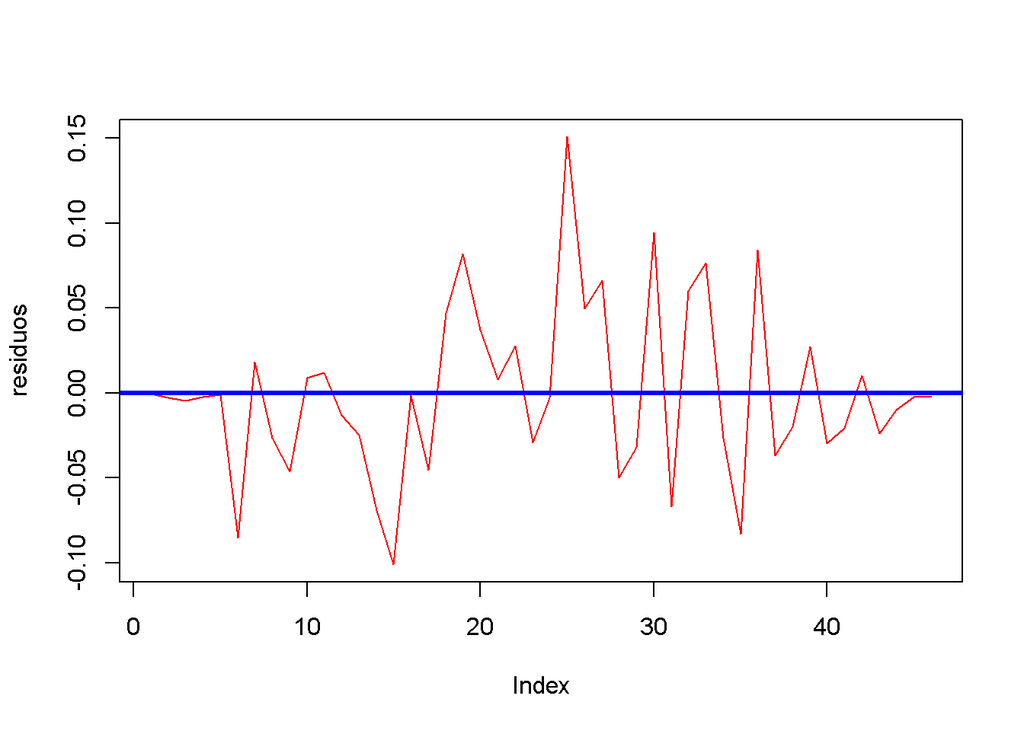

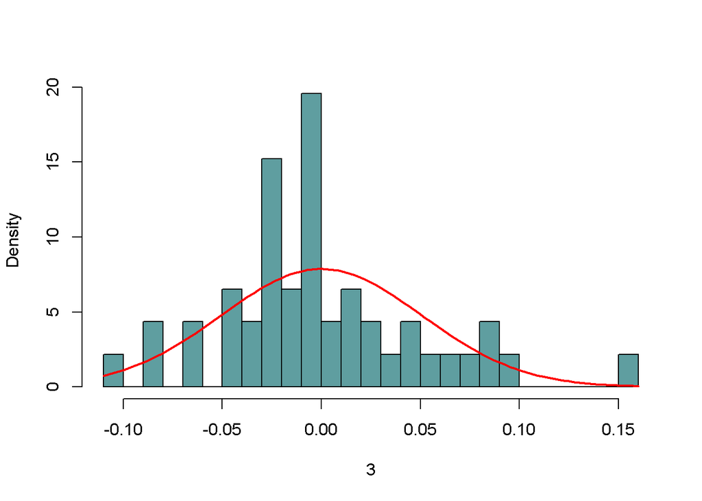

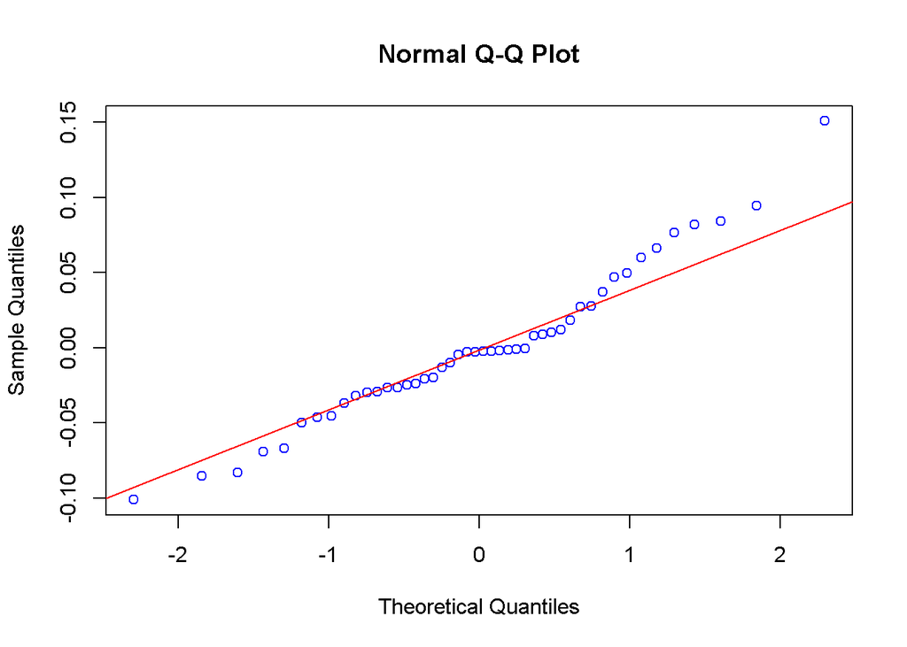

[output not shown]

[output cut: 83 more lines]

```
## $Box.test
##
##  Box-Pierce test
##
## data:  residuos
## X-squared = 14.204, df = 12, p-value = 0.2879
##
##
## $adf
##
##  Augmented Dickey-Fuller Test
##
## data:  residuos
## Dickey-Fuller = -3.2579, Lag order = 3, p-value = 0.08995
## alternative hypothesis: stationary
```

```r
analisar_modelo(`modelo_2019-01-01_até_2022-12-01`)
```

**MODELO VAR**

Os dados ja foram deflacionados

```r
library(fBasics)
library(rbcb)
library(deflateBR)
library(vars)
```

Calculano com os dados brutos

```r
dif_dados <- subset(dif_dados, select = -c(data, Titulo, MesAno))
Dadosn <- left_join(Dadosn, sentimentos_final, by = "data")
Dadosn <- subset(Dadosn, select = -c(data, Titulo, MesAno))
dev.new(width = 800, height = 600)
Dadosn <- na.omit(Dadosn)

VARselect(Dadosn, lag.max =12)
```

```
## $selection
## AIC(n)  HQ(n)  SC(n) FPE(n)
##      5      2      2      5
##
## $criteria
##                 1           2           3          4           5           6
## AIC(n) -1.4285588 -2.74086590 -2.72767890 -2.7283754 -2.85178150 -2.76699319
## HQ(n)  -1.2527112 -2.41847866 -2.25875200 -2.1129089 -2.08977528 -1.85844733
## SC(n)  -0.9921826 -1.94084291 -1.56400909 -1.2010588 -0.96081806 -0.51238294
## FPE(n)  0.2396667  0.06453546  0.06543643  0.0654739  0.05799147  0.06331425
##                  7           8           9          10         11          12
## AIC(n) -2.67636375 -2.60526476 -2.62479211 -2.58927007 -2.5577904 -2.49286536
## HQ(n)  -1.62127823 -1.40363958 -1.27662728 -1.09456558 -0.9165463 -0.70508156
## SC(n)  -0.05810669  0.37663913  0.72075858  1.11992744  1.5150539  1.94362578
## FPE(n)  0.06961228  0.07516023  0.07423769  0.07761718  0.0809891  0.08758268
```

```r
{
  VAR1 = VAR(Dadosn, p=5, type = "none")
  summary(VAR1)
  #plot(VAR1)

  VAR1c = VAR(Dadosn, p = 2, type = "const")
  summary(VAR1c)
  #plot(VAR1c)

  VAR1t = VAR(Dadosn, p=2, type = 'trend')
  summary(VAR1t)
 #plot(VAR1t)
}
```

```
##
## VAR Estimation Results:
## =========================
## Endogenous variables: selic, desvio, hiato, cambio, pontuacao_total_sentimento
## Deterministic variables: trend
## Sample size: 249
## Log Likelihood: -1504.684
## Roots of the characteristic polynomial:
##  0.97 0.9603 0.8675 0.8675 0.8322 0.7569 0.7569 0.1618 0.08847 0.08621
## Call:
## VAR(y = Dadosn, p = 2, type = "trend")
##
##
## Estimation results for equation selic:
## ======================================
## selic = selic.l1 + desvio.l1 + hiato.l1 + cambio.l1 + pontuacao_total_sentimento.l1 + selic.l2 + desvio.l2 + hiato.l2 + cambio.l2 + pontuacao_total_sentimento.l2 + trend
##
##                                 Estimate Std. Error t value Pr(>|t|)
## selic.l1                       1.793e+00  3.662e-02  48.948  < 2e-16 ***
## desvio.l1                      6.962e-02  2.019e-02   3.449 0.000666 ***
## hiato.l1                      -1.662e-02  3.954e-02  -0.420 0.674692
## cambio.l1                      4.854e-02  1.057e-01   0.459 0.646451
## pontuacao_total_sentimento.l1 -7.108e-05  3.000e-04  -0.237 0.812897
## selic.l2                      -8.020e-01  3.596e-02 -22.303  < 2e-16 ***
## desvio.l2                     -3.497e-02  2.032e-02  -1.721 0.086533 .
## hiato.l2                       1.170e-02  3.929e-02   0.298 0.766122
## cambio.l2                     -3.310e-02  1.056e-01  -0.313 0.754227
## pontuacao_total_sentimento.l2  1.098e-04  3.003e-04   0.366 0.714954
## trend                          8.631e-05  3.900e-04   0.221 0.825039
## ---
## Signif. codes:  0 '***' 0.001 '**' 0.01 '*' 0.05 '.' 0.1 ' ' 1
##
##
## Residual standard error: 0.2384 on 238 degrees of freedom
## Multiple R-Squared: 0.9996,  Adjusted R-squared: 0.9996
## F-statistic: 5.906e+04 on 11 and 238 DF,  p-value: < 2.2e-16
##
##
## Estimation results for equation desvio:
## =======================================
```

[output cut: 111 more lines]

```
## pontuacao_total_sentimento                  2707.4057
##
## Correlation matrix of residuals:
##                                selic    desvio    hiato    cambio
## selic                       1.000000 -0.029122 0.000572 -0.082634
## desvio                     -0.029122  1.000000 0.014086 -0.005768
## hiato                       0.000572  0.014086 1.000000  0.002947
## cambio                     -0.082634 -0.005768 0.002947  1.000000
## pontuacao_total_sentimento -0.089342  0.092221 0.052718 -0.096013
##                            pontuacao_total_sentimento
## selic                                        -0.08934
## desvio                                        0.09222
## hiato                                         0.05272
## cambio                                       -0.09601
## pontuacao_total_sentimento                    1.00000
```

```r
plot(irf(VAR1, n.ahead = 24, impulse = "pontuacao_total_sentimento", response = "selic", boot = T))
```

[output not shown]

calculando com diff nos dados (sentimento ainda ta bruto)

```r
VARselect(dif_dados, lag.max =12)
```

```
## $selection
## AIC(n)  HQ(n)  SC(n) FPE(n)
##      4      1      1      4
##
## $criteria
##                    1             2             3             4             5
## AIC(n) -7.8565330420 -7.8281279733 -7.8974640864 -7.9453740400 -7.8689158756
## HQ(n)  -7.6806854549 -7.5057407302 -7.4285371873 -7.3299074850 -7.1069096647
## SC(n)  -7.4201568639 -7.0281049802 -6.7337942782 -6.4180574168 -5.9779524373
## FPE(n)  0.0003872344  0.0003985002  0.0003720578  0.0003551031  0.0003841054
##                    6             7             8             9            10
## AIC(n) -7.7881443851 -7.7714135189 -7.8548585191 -7.8406550051 -7.8337964740
## HQ(n)  -6.8795985182 -6.7163279961 -6.6532333404 -6.4924901705 -6.3390919834
## SC(n)  -5.5335341317 -5.1531564505 -4.8729546357 -4.4951043066 -4.1245989604
## FPE(n)  0.0004176795  0.0004265146  0.0003945649  0.0004030918  0.0004095331
##                   11            12
## AIC(n) -7.8330493651 -7.7545326152
## HQ(n)  -6.1918052186 -5.9667488127
## SC(n)  -3.7602050365 -3.3180414715
## FPE(n)  0.0004143914  0.0004542607
```

```r
{
  VAR1 = VAR(dif_dados, p=1, type = "none")
  summary(VAR1)
  #plot(VAR1)

  VAR1c = VAR(dif_dados, p = 2, type = "const")
  summary(VAR1c)
  #plot(VAR1c)

  VAR1t = VAR(dif_dados, p=4, type = 'trend')
  summary(VAR1t)
 #plot(VAR1t)
}
```

```
##
## VAR Estimation Results:
## =========================
## Endogenous variables: selic, desvio, hiato, cambio, pontuacao_total_sentimento
## Deterministic variables: trend
## Sample size: 247
## Log Likelihood: -672.805
## Roots of the characteristic polynomial:
## 0.955 0.8208 0.6895 0.6895 0.6645 0.6645 0.6614 0.6614 0.6274 0.6274 0.6233 0.6233 0.5986 0.5986 0.5917 0.5917 0.5578 0.4725 0.4725 0.4722
## Call:
## VAR(y = dif_dados, p = 4, type = "trend")
##
##
## Estimation results for equation selic:
## ======================================
## selic = selic.l1 + desvio.l1 + hiato.l1 + cambio.l1 + pontuacao_total_sentimento.l1 + selic.l2 + desvio.l2 + hiato.l2 + cambio.l2 + pontuacao_total_sentimento.l2 + selic.l3 + desvio.l3 + hiato.l3 + cambio.l3 + pontuacao_total_sentimento.l3 + selic.l4 + desvio.l4 + hiato.l4 + cambio.l4 + pontuacao…
##
##                                 Estimate Std. Error t value Pr(>|t|)
## selic.l1                       6.126e-01  6.345e-02   9.656  < 2e-16 ***
## desvio.l1                      1.816e-02  2.873e-03   6.321 1.37e-09 ***
## hiato.l1                       3.547e-03  3.013e-03   1.177 0.240331
## cambio.l1                      1.093e-03  3.665e-02   0.030 0.976239
## pontuacao_total_sentimento.l1 -1.423e-05  3.053e-05  -0.466 0.641615
## selic.l2                       2.032e-01  7.249e-02   2.804 0.005494 **
## desvio.l2                      1.357e-02  3.289e-03   4.126 5.19e-05 ***
## hiato.l2                       4.371e-03  3.170e-03   1.379 0.169300
## cambio.l2                      1.267e-02  3.668e-02   0.345 0.730059
## pontuacao_total_sentimento.l2  9.776e-08  3.977e-05   0.002 0.998041
## selic.l3                       2.512e-01  7.109e-02   3.533 0.000497 ***
## desvio.l3                      1.785e-02  3.222e-03   5.539 8.41e-08 ***
## hiato.l3                      -6.214e-03  3.166e-03  -1.963 0.050913 .
## cambio.l3                     -3.197e-02  3.653e-02  -0.875 0.382431
## pontuacao_total_sentimento.l3  6.439e-05  3.988e-05   1.615 0.107776
## selic.l4                      -2.304e-01  5.894e-02  -3.909 0.000122 ***
## desvio.l4                      5.977e-03  3.104e-03   1.925 0.055434 .
## hiato.l4                      -4.066e-03  2.967e-03  -1.370 0.171988
## cambio.l4                     -4.164e-02  3.624e-02  -1.149 0.251787
## pontuacao_total_sentimento.l4 -2.889e-05  3.128e-05  -0.924 0.356681
## trend                          1.928e-05  1.627e-05   1.185 0.237236
## ---
```

[output cut: 161 more lines]

```
## pontuacao_total_sentimento                 2625.28127
##
## Correlation matrix of residuals:
##                                selic    desvio   hiato   cambio
## selic                       1.000000  0.070284 0.07051 -0.13781
## desvio                      0.070284  1.000000 0.01917 -0.04819
## hiato                       0.070506  0.019166 1.00000  0.02770
## cambio                     -0.137811 -0.048194 0.02770  1.00000
## pontuacao_total_sentimento -0.002241 -0.002386 0.08113 -0.04628
##                            pontuacao_total_sentimento
## selic                                       -0.002241
## desvio                                      -0.002386
## hiato                                        0.081134
## cambio                                      -0.046275
## pontuacao_total_sentimento                   1.000000
```

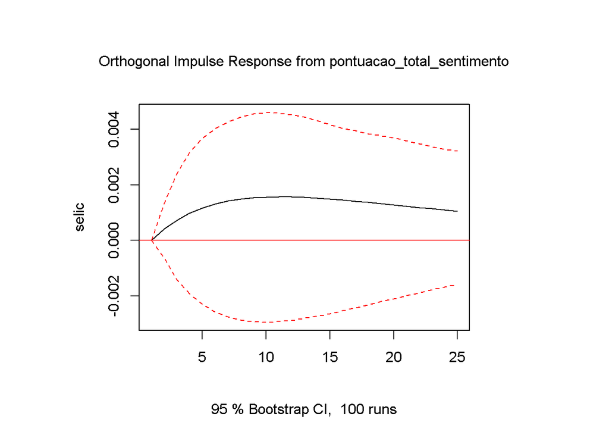

```r
plot(irf(VAR1, n.ahead = 24, impulse = "pontuacao_total_sentimento", response = "selic", boot = T))
```

## Conclusoes

Para melhorar a eficácia do índice de sentimento, é necessário revisá-lo. Uma abordagem seria testar diferentes dicionários para medir o sentimento ou até mesmo modificar a metodologia. Além disso, considerar a utilização de um modelo que pondera as palavras e atribui um “peso” à importância de cada termo pode ser mais eficaz na tradução do sentimento das atas do Copom..

## Referencias

**BARBOSA**, R. B. Impactos da incerteza macroeconômica sobre a situação fiscal no Brasil. [s. l.],

BERNANKE, B. S. Irreversibility, Uncertainty, and Cyclical Investment. **The Quarterly Journal of Economics**, [s. l.], v. 98, n. 1, p. 85, 1983.

KNIGHT, F. H. **Risk, uncertainty and profit**. Mineola, NY: Dover Publications, 2006.

SANTANA, Caio Vinicius Santos et al. Investor sentiment and earnings management in Brazil. **Revista Contabilidade & Finanças**, [s. l.], v. 31, n. 83, p. 283–301, 2020.

SILVA, P. H. N.; BESARRIA, C. D. N.; SILVA, M. D. D. O. P. D. Mensurando e avaliando os efeitos de um choque de incerteza da política econômica sobre a economia brasileira. **Economia Aplicada**, [s. l.], v. 26, n. 3, p. 335–374, 2022.

VALCAREGGI, S. M. **Análise de sentimentos para o mercado brasileiro**. 2022. Mestrado em Economia Aplicada - Universidade de São Paulo, Ribeirão Preto, 2022.

Disponível em:https://www.teses.usp.br/teses/disponiveis/96/96131/tde-24012023-165235/.